# Ratio of senses

Last updated 2018-04-07

This is an exploration of the “ratio of senses” ideas pioneered by Josh Brahinsky.

# Packet 1

Josh identified the following items as relevant to different sensory modalities:

- Seeing:
  - “Spiritual events” (Luhrmann) questions #4, 5 (`spev_04`, `spev_05`)
  - “Absorption” (Tellegen) questions #17, 22 (`exwl_17`, `exwl_22`)
- Hearing:
  - “Spiritual events” (Luhrmann) questions #1, 2, 3 (`spev_01`, `spev_02`, `spev_03`)
  - “Absorption” (Tellegen) questions #12, 24, 25, 30 (`exwl_12`, `exwl_24`, `exwl_25`, `exwl_30`)
- Feeling (tactile/bodily/emotional):
  - “Spiritual events” (Luhrmann) questions #6, 13, 14, 15, 17, 19, 22 (`spev_06`, `spev_13`, `spev_14`, `spev_15`, `spev_17`, `spev_19`, `spev_22`)
  - “Absorption” (Tellegen) question #29 (`exwl_29`)
- Smelling:
  - “Spiritual events” (Luhrmann) question #7 (`spev_07`)
  - “Absorption” (Tellegen) question #26 (`exwl_26`)
- Tasting:
  - “Spiritual events” (Luhrmann) question #8 (`spev_08`)
- Tangible presence:
  - “Daily spiritual experiences” (Underwood & Teresi) question #1 (`dse_01`)
  - “Spiritual events” (Luhrmann) questions #10, 11, 12 (`spev_10`, `spev_11`, `spev_12`)
  - “Absorption” (Tellegen) questions #14, 31 (`exwl_14`, `exwl_31`)
- Dreaming:
  - “Spiritual events” (Luhrmann) question #9 (`spev_09`)
- Observing/healing:
  - “Spiritual events” (Luhrmann) question #21 (`spev_21`)
- Out of body:
  - “Spiritual events” (Luhrmann) question #16 (`spev_16`)

Let’s check out how endorsements of these different sensory experiences varied across sites.

There are many ways we could do this… here’s what I decided on for a first pass. First, I “normalized” all reponses to range from 0-1 (instead of responses to Tellegen ranging from 0-1, responses to Luhrmann rarnging from 0-4, responses to Underwood & Teresi ranging from 0-5, etc.). Then I gave each participant a score on each sense by averaging their responses to all of the questions that Josh deemed relevant to that sense - for some senses (e.g., tasting) this was just a single question, but for other senses (e.g., seeing, hearing feeling) this is an average for many different questions. That seemed like the fairest way to give each sense equal opportunity here, though it’s not perfect.

## Means by site

Here are two (equivalent) ways of visualizing these data:

### Comparing sensory modalities within each site

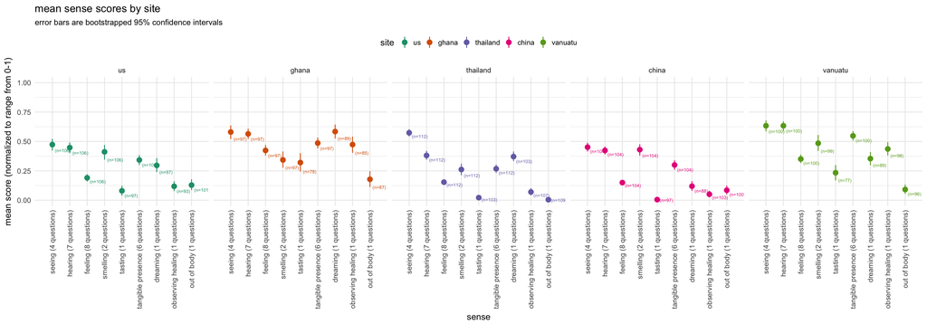

Check out seeing vs. hearing in Thailand vs. the other sites! Also, the relative emphasis on feeling (compared to, e.g., seeing/hearing) seems to differ in reasonable ways (e.g., relatively more endorsement in Ghana). Smelling is higher in the US than I would have predicted, and lower in Thailand than Felicity might have predicted.

### Comparing sites within a sensory modality

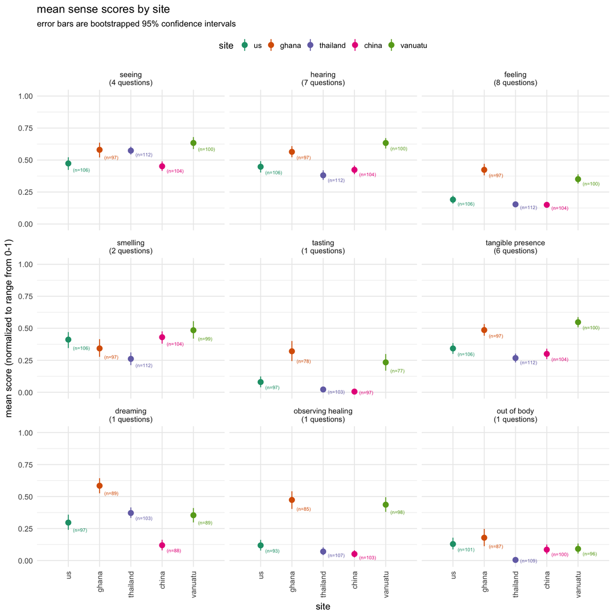

These are the same data, visualized in a different way. Take this with a grain of salt - it might make you miss out on some general response tendencies that are more obvious from the previous visualization (e.g., that people in Ghana and Vanuatu generally responded more positively to all of these items than people in other sites).

## Responses to individual questions

We could (and should) also look at responses to particular items. Let’s do it:

```
Column `question` joining character vector and factor, coercing into character vectorIgnoring unknown aesthetics: fill
```

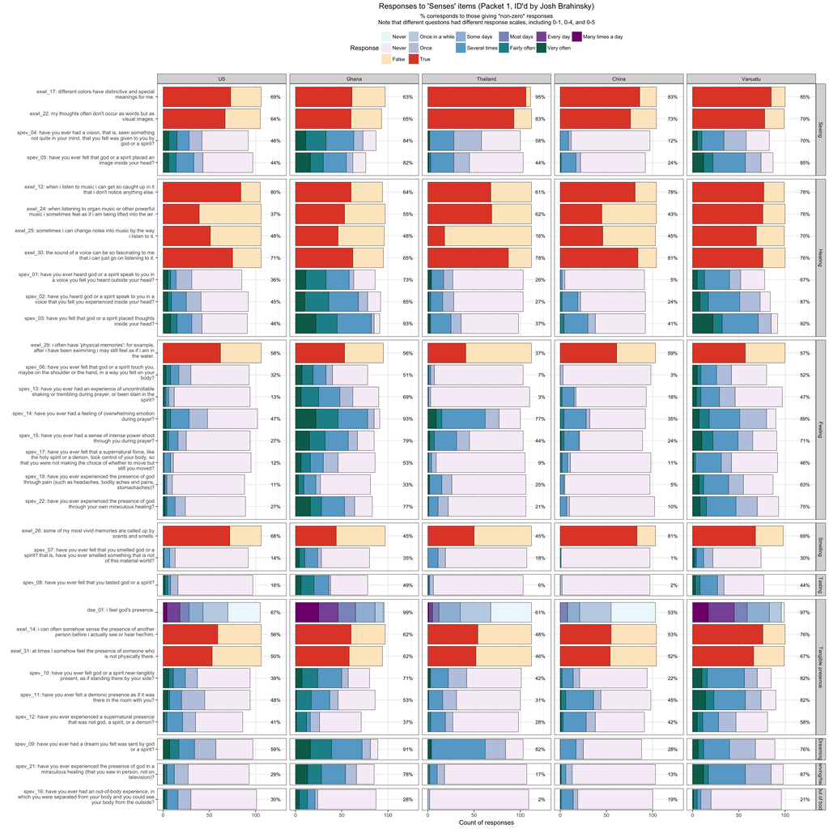

Lots to look through here! Let me know what you see.